# Rafael_Carvalho_LogRegression_Project

RAFAEL SOARES DE CARVALHO

Logistic Regression Modeling

Texas University

### Objective:

The classification goal is to predict the likelihood of a liability customer buying personal loans.

## Tasks

1a) Import the datasets and libraries, check datatype, statistical summary, shape, null values or incorrect imputation.

```python
#Import Libraries
import warnings
warnings.filterwarnings('ignore')

import numpy as np

from sklearn.linear_model import LinearRegression
from sklearn.model_selection import train_test_split
from sklearn.linear_model import LogisticRegression
from sklearn import metrics
from sklearn.metrics import confusion_matrix, recall_score, precision_score, f1_score, roc_auc_score,accuracy_score,roc_curve


import statsmodels.api as sm

import pandas as pd

import matplotlib.pyplot as plt
%matplotlib inline

import seaborn as sns

import scipy.stats as stats

# Remove scientific notations and display numbers with 2 decimal points instead
pd.options.display.float_format = '{:,.2f}'.format
```

```python
#Import Dataset
bank = pd.read_csv("Bank_Personal_Loan_Modelling.csv")
```

1b) - Check and understand Data

```python
#Check import consistency
bank.shape
#Review: Import Validated 5k regs and 14 information collumns
```

```
(5000, 14)
```

```python
#top10 view
bank.head()
#top 10 rows for data exploration
```

|  | ID | Age | Experience | Income | ZIP Code | Family | CCAvg | Education | Mortgage | Personal Loan | Securities Account | CD Account | Online | CreditCard |
| --- | --- | --- | --- | --- | --- | --- | --- | --- | --- | --- | --- | --- | --- | --- |
| 0 | 1 | 25 | 1 | 49 | 91107 | 4 | 1.60 | 1 | 0 | 0 | 1 | 0 | 0 | 0 |
| 1 | 2 | 45 | 19 | 34 | 90089 | 3 | 1.50 | 1 | 0 | 0 | 1 | 0 | 0 | 0 |
| 2 | 3 | 39 | 15 | 11 | 94720 | 1 | 1.00 | 1 | 0 | 0 | 0 | 0 | 0 | 0 |
| 3 | 4 | 35 | 9 | 100 | 94112 | 1 | 2.70 | 2 | 0 | 0 | 0 | 0 | 0 | 0 |
| 4 | 5 | 35 | 8 | 45 | 91330 | 4 | 1.00 | 2 | 0 | 0 | 0 | 0 | 0 | 1 |

```python
#Statistical information and summary
bank.describe()
#Alert: Experience has negative values- inconsistency results (no sense to be minus than zero)
```

|  | ID | Age | Experience | Income | ZIP Code | Family | CCAvg | Education | Mortgage | Personal Loan | Securities Account | CD Account | Online | CreditCard |
| --- | --- | --- | --- | --- | --- | --- | --- | --- | --- | --- | --- | --- | --- | --- |
| count | 5,000.00 | 5,000.00 | 5,000.00 | 5,000.00 | 5,000.00 | 5,000.00 | 5,000.00 | 5,000.00 | 5,000.00 | 5,000.00 | 5,000.00 | 5,000.00 | 5,000.00 | 5,000.00 |
| mean | 2,500.50 | 45.34 | 20.10 | 73.77 | 93,152.50 | 2.40 | 1.94 | 1.88 | 56.50 | 0.10 | 0.10 | 0.06 | 0.60 | 0.29 |
| std | 1,443.52 | 11.46 | 11.47 | 46.03 | 2,121.85 | 1.15 | 1.75 | 0.84 | 101.71 | 0.29 | 0.31 | 0.24 | 0.49 | 0.46 |
| min | 1.00 | 23.00 | -3.00 | 8.00 | 9,307.00 | 1.00 | 0.00 | 1.00 | 0.00 | 0.00 | 0.00 | 0.00 | 0.00 | 0.00 |
| 25% | 1,250.75 | 35.00 | 10.00 | 39.00 | 91,911.00 | 1.00 | 0.70 | 1.00 | 0.00 | 0.00 | 0.00 | 0.00 | 0.00 | 0.00 |
| 50% | 2,500.50 | 45.00 | 20.00 | 64.00 | 93,437.00 | 2.00 | 1.50 | 2.00 | 0.00 | 0.00 | 0.00 | 0.00 | 1.00 | 0.00 |
| 75% | 3,750.25 | 55.00 | 30.00 | 98.00 | 94,608.00 | 3.00 | 2.50 | 3.00 | 101.00 | 0.00 | 0.00 | 0.00 | 1.00 | 1.00 |
| max | 5,000.00 | 67.00 | 43.00 | 224.00 | 96,651.00 | 4.00 | 10.00 | 3.00 | 635.00 | 1.00 | 1.00 | 1.00 | 1.00 | 1.00 |

```python
#Check Data Types
bank.dtypes
#Review: No need to change dataTypes for now
```

```
ID                      int64
Age                     int64
Experience              int64
Income                  int64
ZIP Code                int64
Family                  int64
CCAvg                 float64
Education               int64
Mortgage                int64
Personal Loan           int64
Securities Account      int64
CD Account              int64
Online                  int64
CreditCard              int64
dtype: object
```

```python
#Check Data Infos
bank.info()
```

```
<class 'pandas.core.frame.DataFrame'>
RangeIndex: 5000 entries, 0 to 4999
Data columns (total 14 columns):
 #   Column              Non-Null Count  Dtype
---  ------              --------------  -----
 0   ID                  5000 non-null   int64
 1   Age                 5000 non-null   int64
 2   Experience          5000 non-null   int64
 3   Income              5000 non-null   int64
 4   ZIP Code            5000 non-null   int64
 5   Family              5000 non-null   int64
 6   CCAvg               5000 non-null   float64
 7   Education           5000 non-null   int64
 8   Mortgage            5000 non-null   int64
 9   Personal Loan       5000 non-null   int64
 10  Securities Account  5000 non-null   int64
 11  CD Account          5000 non-null   int64
 12  Online              5000 non-null   int64
 13  CreditCard          5000 non-null   int64
dtypes: float64(1), int64(13)
memory usage: 547.0 KB
```

```python
#Check Duplicated Rows
dup = bank.duplicated()
sum(dup)
#Review: no duplicated lines
```

```
0
```

```python
#Check for Nulls
nulls = bank.isnull().any()
nulls
#Review: no missing values
#bank_adj.isnull().sum()
```

```
ID                    False
Age                   False
Experience            False
Income                False
ZIP Code              False
Family                False
CCAvg                 False
Education             False
Mortgage              False
Personal Loan         False
Securities Account    False
CD Account            False
Online                False
CreditCard            False
dtype: bool
```

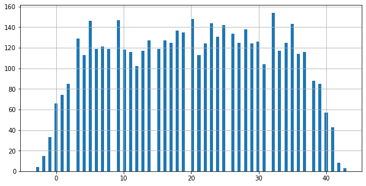

```python
bank['Experience'].hist(stacked=False, bins=100, figsize=(10,5));
```

```python
#Replace experience < 0 for mean of Experience - Incorrect inputation
bank_adj = bank.copy()
bank_adj[(bank_adj['Experience']<0)] = bank_adj['Experience'].mean()
```

```python
bank_adj[(bank_adj['Experience']<0)].count().sum()
#Review: no more negative values for experience
```

```
0
```

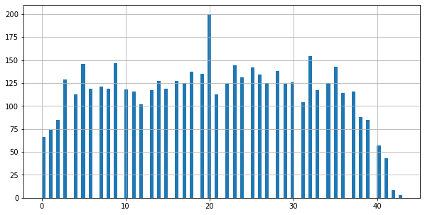

```python
#adjusted histogram of Experience
bank_adj['Experience'].hist(stacked=False, bins=100, figsize=(10,5));
```

```python
#IQR from each collumm
bank_adj.quantile(0.75) - bank_adj.quantile(0.25)
```

```
ID                   2,521.50
Age                     20.00
Experience              19.00
Income                  60.00
ZIP Code             2,833.00
Family                   3.00
CCAvg                    1.90
Education                2.00
Mortgage               100.00
Personal Loan            0.00
Securities Account       0.00
CD Account               0.00
Online                   1.00
CreditCard               1.00
dtype: float64
```

```python
#Range
print(bank_adj.max() - bank_adj.min())
```

```
ID                    4,999.00
Age                      46.90
Experience               43.00
Income                  216.00
ZIP Code             96,630.90
Family                   19.10
CCAvg                    20.10
Education                19.10
Mortgage                635.00
Personal Loan            20.10
Securities Account       20.10
CD Account               20.10
Online                   20.10
CreditCard               20.10
dtype: float64
```

```python
#Standard Deviation
print(bank_adj.std())
```

```
ID                   1,457.65
Age                     11.55
Experience              11.25
Income                  46.19
ZIP Code             9,682.95
Family                   2.13
CCAvg                    2.53
Education                2.03
Mortgage               101.37
Personal Loan            2.05
Securities Account       2.05
CD Account               2.05
Online                   2.04
CreditCard               2.06
dtype: float64
```

```python
#Covariance
cov_bank = (bank_adj.cov())
cov_bank
```

|  | ID | Age | Experience | Income | ZIP Code | Family | CCAvg | Education | Mortgage | Personal Loan | Securities Account | CD Account | Online | CreditCard |
| --- | --- | --- | --- | --- | --- | --- | --- | --- | --- | --- | --- | --- | --- | --- |
| ID | 2,124,753.44 | 491.72 | -146.18 | 235.35 | 2,419,711.03 | -479.28 | -527.96 | -439.23 | -691.77 | -521.63 | -519.10 | -514.35 | -499.30 | -494.72 |
| Age | 491.72 | 133.49 | 126.04 | -15.89 | 23,702.37 | -5.15 | -5.76 | -4.34 | -7.75 | -5.29 | -5.24 | -5.24 | -5.04 | -5.15 |
| Experience | -146.18 | 126.04 | 126.63 | -25.29 | -462.92 | -0.63 | -1.00 | 0.13 | -15.26 | -0.09 | -0.05 | -0.03 | 0.03 | -0.00 |
| Income | 235.35 | -15.89 | -25.29 | 2,133.95 | 50,039.30 | -17.95 | 41.49 | -17.28 | 981.71 | -4.25 | -11.09 | -9.22 | -10.46 | -11.05 |
| ZIP Code | 2,419,711.03 | 23,702.37 | -462.92 | 50,039.30 | 93,759,502.53 | -16,954.48 | -17,427.99 | -17,503.42 | 36,791.69 | -19,180.84 | -19,171.73 | -19,205.33 | -18,681.88 | -18,985.03 |
| Family | -479.28 | -5.15 | -0.63 | -17.95 | -16,954.48 | 4.53 | 3.10 | 3.38 | -9.02 | 3.67 | 3.65 | 3.66 | 3.56 | 3.62 |
| CCAvg | -527.96 | -5.76 | -1.00 | 41.49 | -17,427.99 | 3.10 | 6.42 | 3.21 | 12.52 | 3.93 | 3.75 | 3.81 | 3.65 | 3.70 |
| Education | -439.23 | -4.34 | 0.13 | -17.28 | -17,503.42 | 3.38 | 3.21 | 4.12 | -9.61 | 3.79 | 3.75 | 3.76 | 3.65 | 3.71 |
| Mortgage | -691.77 | -7.75 | -15.26 | 981.71 | 36,791.69 | -9.02 | 12.52 | -9.61 | 10,275.00 | -3.28 | -7.64 | -5.38 | -7.67 | -7.77 |
| Personal Loan | -521.63 | -5.29 | -0.09 | -4.25 | -19,180.84 | 3.67 | 3.93 | 3.79 | -3.28 | 4.21 | 4.12 | 4.15 | 4.02 | 4.08 |
| Securities Account | -519.10 | -5.24 | -0.05 | -11.09 | -19,171.73 | 3.65 | 3.75 | 3.75 | -7.64 | 4.12 | 4.21 | 4.15 | 4.02 | 4.08 |
| CD Account | -514.35 | -5.24 | -0.03 | -9.22 | -19,205.33 | 3.66 | 3.81 | 3.76 | -5.38 | 4.15 | 4.15 | 4.19 | 4.05 | 4.12 |
| Online | -499.30 | -5.04 | 0.03 | -10.46 | -18,681.88 | 3.56 | 3.65 | 3.65 | -7.67 | 4.02 | 4.02 | 4.05 | 4.16 | 3.98 |
| CreditCard | -494.72 | -5.15 | -0.00 | -11.05 | -18,985.03 | 3.62 | 3.70 | 3.71 | -7.77 | 4.08 | 4.08 | 4.12 | 3.98 | 4.25 |

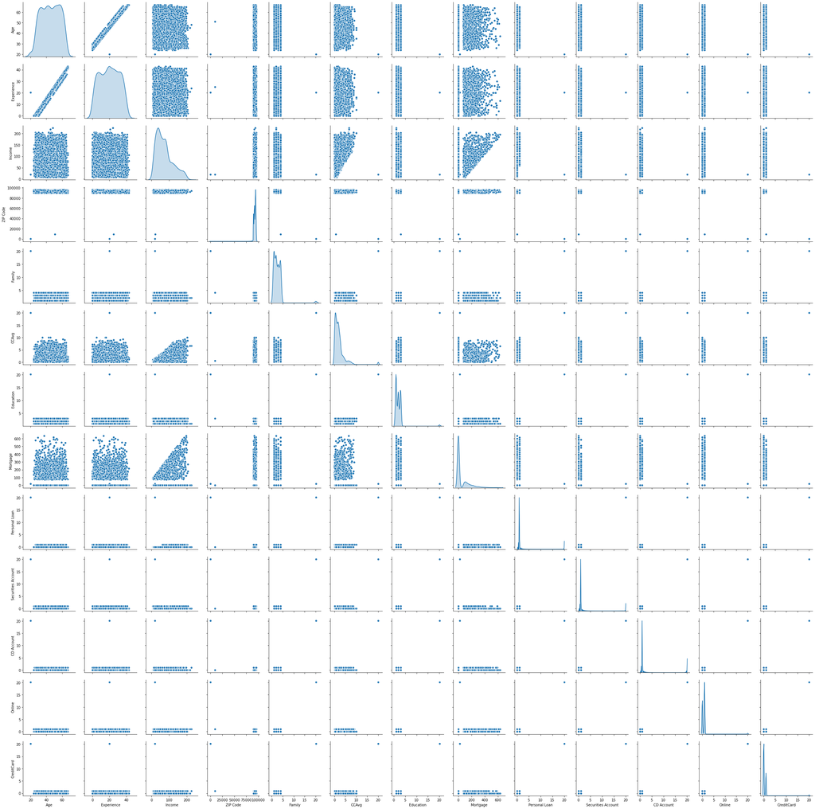

```python
bank_attr = bank_adj.iloc[:, 1:14]
sns.pairplot(bank_attr, diag_kind='kde')
```

```python
bank_adj.corr()
```

|  | ID | Age | Experience | Income | ZIP Code | Family | CCAvg | Education | Mortgage | Personal Loan | Securities Account | CD Account | Online | CreditCard |
| --- | --- | --- | --- | --- | --- | --- | --- | --- | --- | --- | --- | --- | --- | --- |
| ID | 1.00 | 0.03 | -0.01 | 0.00 | 0.17 | -0.15 | -0.14 | -0.15 | -0.00 | -0.17 | -0.17 | -0.17 | -0.17 | -0.16 |
| Age | 0.03 | 1.00 | 0.97 | -0.03 | 0.21 | -0.21 | -0.20 | -0.19 | -0.01 | -0.22 | -0.22 | -0.22 | -0.21 | -0.22 |
| Experience | -0.01 | 0.97 | 1.00 | -0.05 | -0.00 | -0.03 | -0.04 | 0.01 | -0.01 | -0.00 | -0.00 | -0.00 | 0.00 | -0.00 |
| Income | 0.00 | -0.03 | -0.05 | 1.00 | 0.11 | -0.18 | 0.35 | -0.18 | 0.21 | -0.04 | -0.12 | -0.10 | -0.11 | -0.12 |
| ZIP Code | 0.17 | 0.21 | -0.00 | 0.11 | 1.00 | -0.82 | -0.71 | -0.89 | 0.04 | -0.97 | -0.96 | -0.97 | -0.95 | -0.95 |
| Family | -0.15 | -0.21 | -0.03 | -0.18 | -0.82 | 1.00 | 0.57 | 0.78 | -0.04 | 0.84 | 0.84 | 0.84 | 0.82 | 0.82 |
| CCAvg | -0.14 | -0.20 | -0.04 | 0.35 | -0.71 | 0.57 | 1.00 | 0.63 | 0.05 | 0.76 | 0.72 | 0.73 | 0.71 | 0.71 |
| Education | -0.15 | -0.19 | 0.01 | -0.18 | -0.89 | 0.78 | 0.63 | 1.00 | -0.05 | 0.91 | 0.90 | 0.91 | 0.88 | 0.89 |
| Mortgage | -0.00 | -0.01 | -0.01 | 0.21 | 0.04 | -0.04 | 0.05 | -0.05 | 1.00 | -0.02 | -0.04 | -0.03 | -0.04 | -0.04 |
| Personal Loan | -0.17 | -0.22 | -0.00 | -0.04 | -0.97 | 0.84 | 0.76 | 0.91 | -0.02 | 1.00 | 0.98 | 0.99 | 0.96 | 0.97 |
| Securities Account | -0.17 | -0.22 | -0.00 | -0.12 | -0.96 | 0.84 | 0.72 | 0.90 | -0.04 | 0.98 | 1.00 | 0.99 | 0.96 | 0.96 |
| CD Account | -0.17 | -0.22 | -0.00 | -0.10 | -0.97 | 0.84 | 0.73 | 0.91 | -0.03 | 0.99 | 0.99 | 1.00 | 0.97 | 0.98 |
| Online | -0.17 | -0.21 | 0.00 | -0.11 | -0.95 | 0.82 | 0.71 | 0.88 | -0.04 | 0.96 | 0.96 | 0.97 | 1.00 | 0.95 |
| CreditCard | -0.16 | -0.22 | -0.00 | -0.12 | -0.95 | 0.82 | 0.71 | 0.89 | -0.04 | 0.97 | 0.96 | 0.98 | 0.95 | 1.00 |

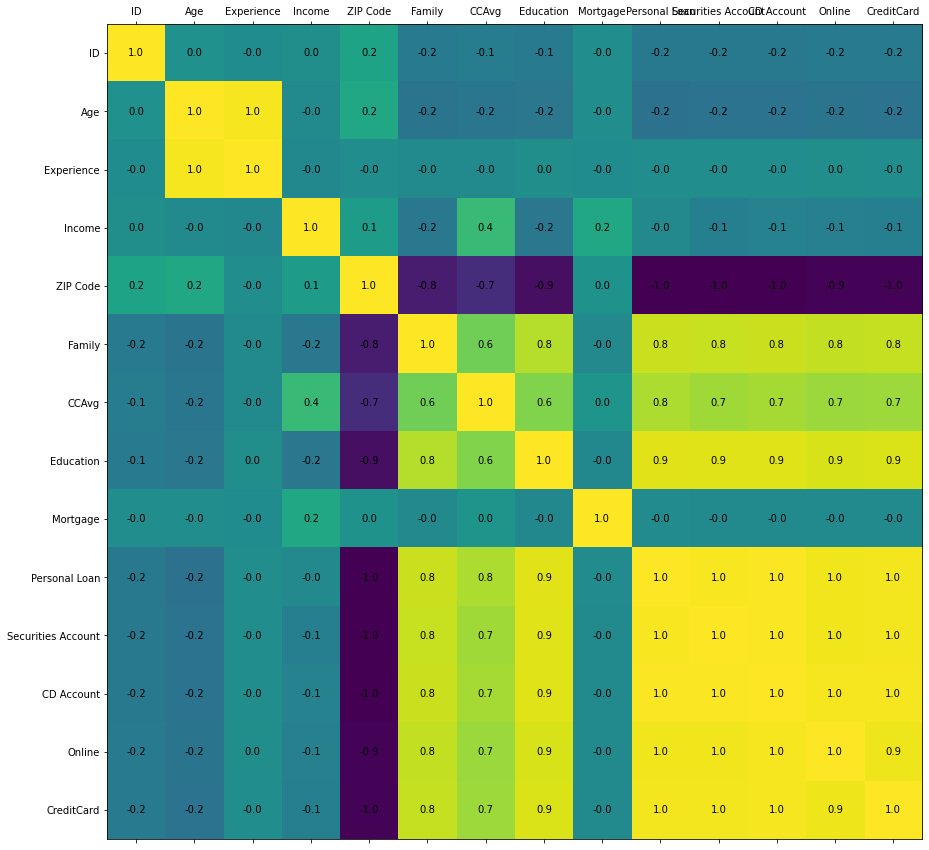

```python
# Graf view of correlation
def plot_correlation(bank_adj):
    corr = bank_adj.corr()
    fig, ax = plt.subplots(figsize=(30, 15))
    ax.matshow(corr)
    plt.xticks(range(len(corr.columns)), corr.columns)
    plt.yticks(range(len(corr.columns)), corr.columns)
    for (i, j), z in np.ndenumerate(corr):
        ax.text(j, i, '{:0.1f}'.format(z), ha='center', va='center')

plot_correlation(bank_adj)
```

```python
# Treat categorical variables
bank_adj['Education'] = bank_adj['Education'].replace({1: 'Undergrad', 2: 'Graduate', 3: 'Advanced/Professional'})
bank_adj.head()
```

|  | ID | Age | Experience | Income | ZIP Code | Family | CCAvg | Education | Mortgage | Personal Loan | Securities Account | CD Account | Online | CreditCard |
| --- | --- | --- | --- | --- | --- | --- | --- | --- | --- | --- | --- | --- | --- | --- |
| 0 | 1.00 | 25.00 | 1.00 | 49.00 | 91,107.00 | 4.00 | 1.60 | Undergrad | 0.00 | 0.00 | 1.00 | 0.00 | 0.00 | 0.00 |
| 1 | 2.00 | 45.00 | 19.00 | 34.00 | 90,089.00 | 3.00 | 1.50 | Undergrad | 0.00 | 0.00 | 1.00 | 0.00 | 0.00 | 0.00 |
| 2 | 3.00 | 39.00 | 15.00 | 11.00 | 94,720.00 | 1.00 | 1.00 | Undergrad | 0.00 | 0.00 | 0.00 | 0.00 | 0.00 | 0.00 |
| 3 | 4.00 | 35.00 | 9.00 | 100.00 | 94,112.00 | 1.00 | 2.70 | Graduate | 0.00 | 0.00 | 0.00 | 0.00 | 0.00 | 0.00 |
| 4 | 5.00 | 35.00 | 8.00 | 45.00 | 91,330.00 | 4.00 | 1.00 | Graduate | 0.00 | 0.00 | 0.00 | 0.00 | 0.00 | 1.00 |

```python
#skewness of data
bank_adj.skew()
```

```
ID                    0.00
Age                  -0.06
Experience           -0.01
Income                0.85
ZIP Code             -9.09
Family                5.75
CCAvg                 4.13
Mortgage              2.12
Personal Loan         9.36
Securities Account    9.34
CD Account            9.46
Online                8.81
CreditCard            8.96
dtype: float64
```

2) - EDA - Check and understand Data

## a - Number of unique in each column?

```python
x = bank_adj.columns
for x,y in enumerate(bank_adj.columns):
    print("{} - The Number of Unique Values for {} is {}".format(x,y,len(bank_adj[y].unique()) ))
```

```
0 - The Number of Unique Values for ID is 4949
1 - The Number of Unique Values for Age is 45
2 - The Number of Unique Values for Experience is 45
3 - The Number of Unique Values for Income is 163
4 - The Number of Unique Values for ZIP Code is 468
5 - The Number of Unique Values for Family is 5
6 - The Number of Unique Values for CCAvg is 109
7 - The Number of Unique Values for Education is 4
8 - The Number of Unique Values for Mortgage is 348
9 - The Number of Unique Values for Personal Loan is 3
10 - The Number of Unique Values for Securities Account is 3
11 - The Number of Unique Values for CD Account is 3
12 - The Number of Unique Values for Online is 3
13 - The Number of Unique Values for CreditCard is 3
```

## b - Number of people with zero mortgage?

```python
print("The number of rows with zero mortagage is {}".format(bank_adj[(bank_adj['Mortgage']==0)].Mortgage.value_counts().max()))

#double check if there is non unique ID
print("The number of people (unique ID) with zero mortagage is {}".format(len(bank_adj[(bank_adj['Mortgage']==0)].ID.unique())))
```

```
The number of rows with zero mortagage is 3422
The number of people (unique ID) with zero mortagage is 3422
```

## c - Number of people with zero credit card spending per month?

```python
print("The number of rows with zero Credit Card Spending is {}".format(bank_adj[(bank_adj['CCAvg']==0)].CCAvg.value_counts().max()))

#double check if there is non unique ID
print("The number of people (unique ID) with zero Credit Card Spending is {}".format(len(bank_adj[(bank_adj['CCAvg']==0)].ID.unique())))

print("\nCredit Card Spending \n",bank_adj.groupby("CCAvg")["ID"].count())
```

```
The number of rows with zero Credit Card Spending is 106
The number of people (unique ID) with zero Credit Card Spending is 106

Credit Card Spending
 CCAvg
0.00     106
0.10     183
0.20     203
0.30     238
0.40     177
        ...
8.90       1
9.00       2
9.30       1
10.00      3
20.10     52
Name: ID, Length: 109, dtype: int64
```

## d - Value counts of all categorical columns.

#### Categorical Variables - finite numbers, defined, listed, boolean ..etc.

```
# Education: Education Level. 1: Undergrad; 2: Graduate; 3: Advanced/Professional
# Personal Loan: Did this customer accept the personal loan offered in the last campaign?
# Securities Account: Does the customer have a securities account with the bank?
# CD Account: Does the customer have a certificate of deposit (CD) account with the bank?
# Online: Does the customer use internet banking facilities?
# Credit card: Does the customer use a credit card issued by the bank?
```

#### Other Variables

```
# ID: Customer ID
# Age: Customer's age in completed years
# Income: Annual income of the customer (000)
# ZIP Code: Home Address ZIP code.
# CCAvg: Avg. spending on credit cards per month (000)
# Mortgage: Value of house mortgage if any. (000)
# Family: Family size of the customer
# Experience: #years of professional experience
```

```python
Cat_Vars = ['Education','Personal Loan','Securities Account','CD Account','Online','CreditCard']

for x,y in enumerate(Cat_Vars):
#    print("{} - The Number of Unique Values for {} is {}".format(x,y,len(bank_adj[y].unique()) ))
    print("{}\n ".format(bank_adj.groupby(y)["ID"].count()))

# As Dataset is
```

```
Education
20.1046                    52
Advanced/Professional    1481
Graduate                 1387
Undergrad                2080
Name: ID, dtype: int64

Personal Loan
0.00     4468
1.00      480
20.10      52
Name: ID, dtype: int64

Securities Account
0.00     4432
1.00      516
20.10      52
Name: ID, dtype: int64

CD Account
0.00     4646
1.00      302
20.10      52
Name: ID, dtype: int64

Online
0.00     1994
1.00     2954
20.10      52
Name: ID, dtype: int64

CreditCard
0.00     3493
1.00     1455
20.10      52
Name: ID, dtype: int64
```

```python
# Treat categorical variables
bank_adj['Education'] = bank_adj['Education'].replace({1: 'Undergrad', 2: 'Graduate', 3: 'Advanced/Professional', 20.1046: 'N/A'})
bank_adj['Personal Loan'] = bank_adj['Personal Loan'].replace({1: 'Yes', 0: 'No', 20.1046: 'N/A'})
bank_adj['Securities Account'] = bank_adj['Securities Account'].replace({1: 'Yes', 0: 'No', 20.1046: 'N/A'})
bank_adj['CD Account'] = bank_adj['CD Account'].replace({1: 'Yes', 0: 'No', 20.1046: 'N/A'})
bank_adj['Online'] = bank_adj['Online'].replace({1: 'Yes', 0: 'No', 20.1046: 'N/A'})
bank_adj['CreditCard'] = bank_adj['CreditCard'].replace({1: 'Yes', 0: 'No', 20.1046: 'N/A'})

bank_adj.head()
```

|  | ID | Age | Experience | Income | ZIP Code | Family | CCAvg | Education | Mortgage | Personal Loan | Securities Account | CD Account | Online | CreditCard |
| --- | --- | --- | --- | --- | --- | --- | --- | --- | --- | --- | --- | --- | --- | --- |
| 0 | 1.00 | 25.00 | 1.00 | 49.00 | 91,107.00 | 4.00 | 1.60 | Undergrad | 0.00 | No | Yes | No | No | No |
| 1 | 2.00 | 45.00 | 19.00 | 34.00 | 90,089.00 | 3.00 | 1.50 | Undergrad | 0.00 | No | Yes | No | No | No |
| 2 | 3.00 | 39.00 | 15.00 | 11.00 | 94,720.00 | 1.00 | 1.00 | Undergrad | 0.00 | No | No | No | No | No |
| 3 | 4.00 | 35.00 | 9.00 | 100.00 | 94,112.00 | 1.00 | 2.70 | Graduate | 0.00 | No | No | No | No | No |
| 4 | 5.00 | 35.00 | 8.00 | 45.00 | 91,330.00 | 4.00 | 1.00 | Graduate | 0.00 | No | No | No | No | Yes |

```python
Cat_Vars = ['Education','Personal Loan','Securities Account','CD Account','Online','CreditCard']

for x,y in enumerate(Cat_Vars):
    print("{}\n ".format(bank_adj.groupby(y)["ID"].count().sort_values(ascending = False)))

# Adjusted values
```

```
Education
Undergrad                2080
Advanced/Professional    1481
Graduate                 1387
N/A                        52
Name: ID, dtype: int64

Personal Loan
No     4468
Yes     480
N/A      52
Name: ID, dtype: int64

Securities Account
No     4432
Yes     516
N/A      52
Name: ID, dtype: int64

CD Account
No     4646
Yes     302
N/A      52
Name: ID, dtype: int64

Online
Yes    2954
No     1994
N/A      52
Name: ID, dtype: int64

CreditCard
No     3493
Yes    1455
N/A      52
Name: ID, dtype: int64
```

## e - Univariate and Bivariate Analysis

##### UNIVARIATED ANALYSIS

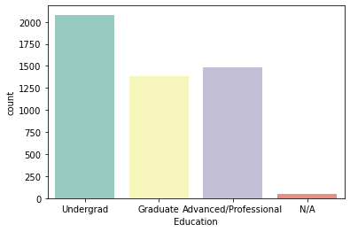

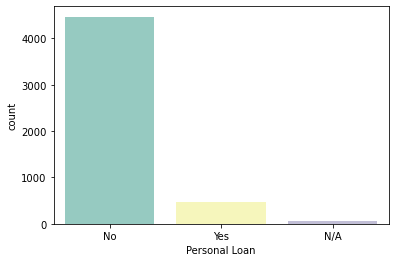

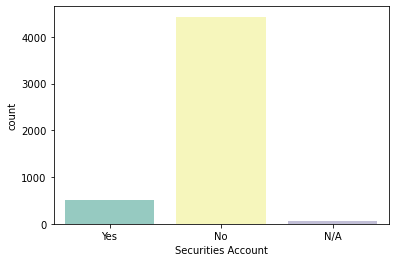

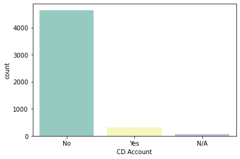

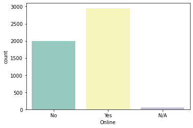

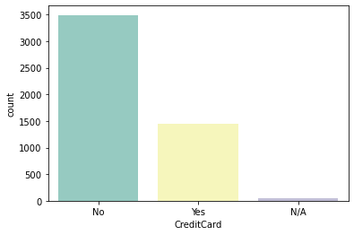

```python
#CountPlot for Categorical Variables
for x, y in enumerate(Cat_Vars):
    sns.countplot(bank_adj[y],palette="Set3")
    plt.show()
```

### As we can see:

##### - NA values is present in all collumms

##### - Most of people dont have securities account and CD Account

##### - Online, CreditCard, Education have good distribution of data for most customers

```python
# for non Categorical Variables
Non_Cat_Vars = ['Age','Income','ZIP Code','CCAvg','Mortgage','Family','Experience']
```

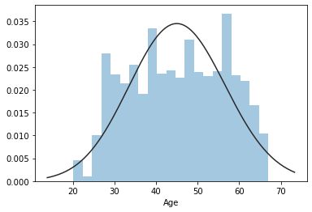

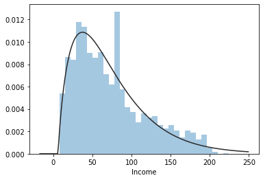

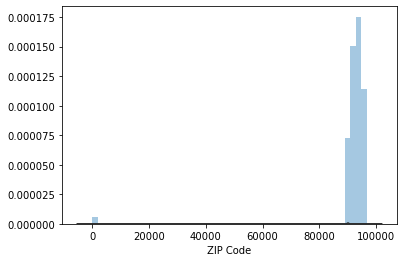

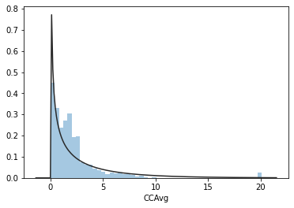

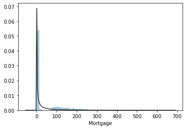

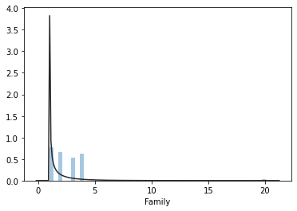

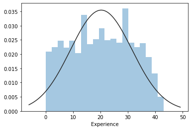

```python
# Histogram
for x, y in enumerate(Non_Cat_Vars):
    sns.distplot(bank_adj[y],fit=stats.gamma,kde=False)
    plt.show()
```

# As we can see:

##### - Outliers is present in most collums

##### - Mortgage has many zeros and low values, then some customers near 100-200

##### - Family has some mistake in data, with outliers (>20)

##### - Boxplots show how data has dispersion above IQR

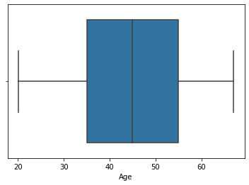

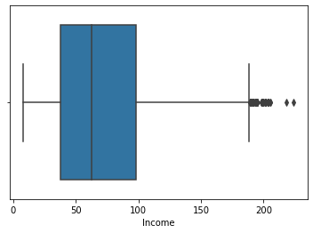

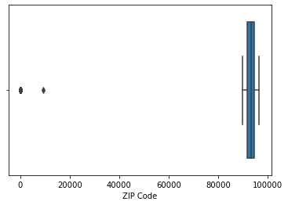

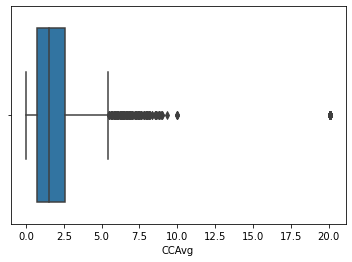

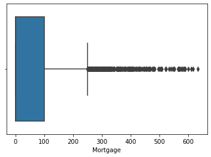

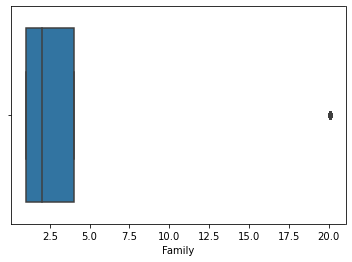

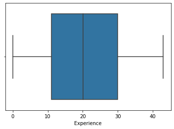

```python
# BoxPlots
for x, y in enumerate(Non_Cat_Vars):
    sns.boxplot(bank_adj[y])
    plt.show()
```

##### BIVARIATED ANALYSIS

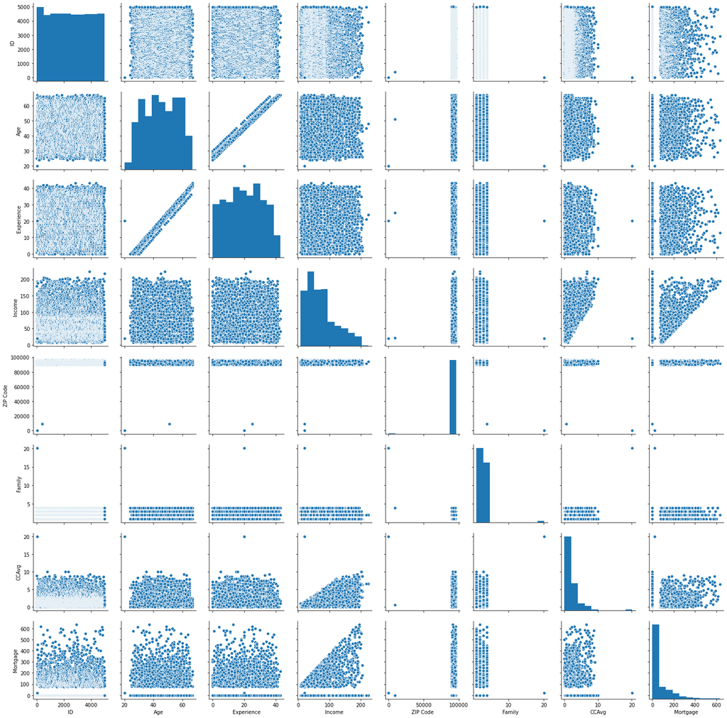

```python
# PAIRPLOT TO SEE HOW DATA MAY BE CORRELATED
sns.pairplot(bank_adj)
plt.show()
```

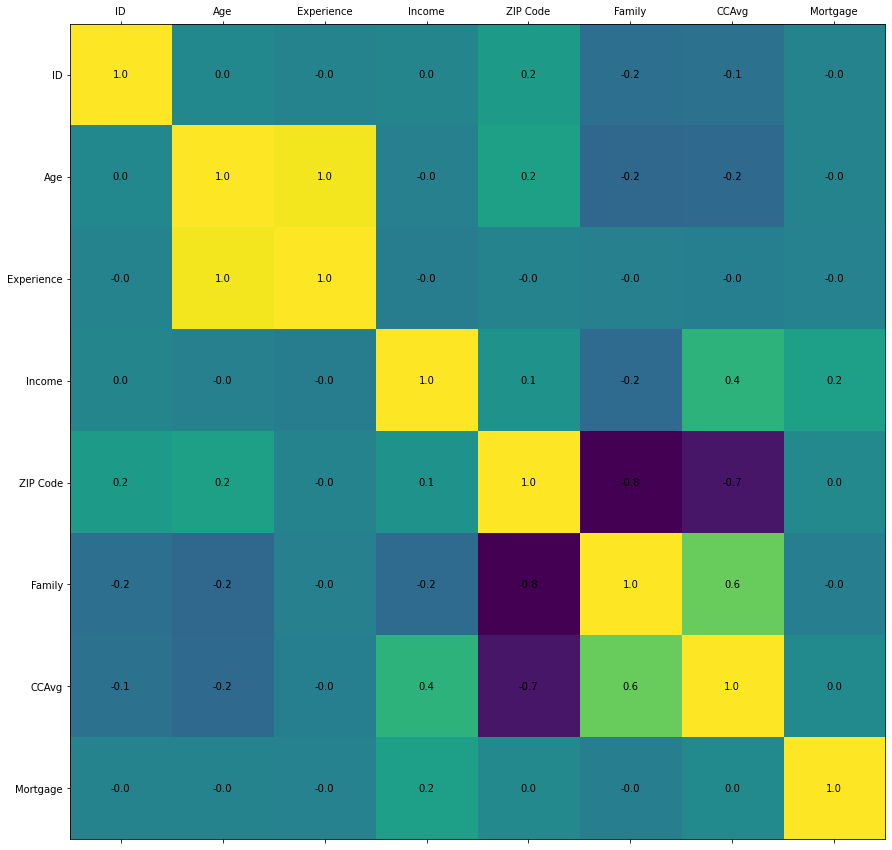

```python
# CORRELATION BETWEEN VARIABLES
def plot_correlation(bank_adj):
    corr = bank_adj.corr()
    fig, ax = plt.subplots(figsize=(30, 15))
    ax.matshow(corr)
    plt.xticks(range(len(corr.columns)), corr.columns)
    plt.yticks(range(len(corr.columns)), corr.columns)
    for (i, j), z in np.ndenumerate(corr):
        ax.text(j, i, '{:0.1f}'.format(z), ha='center', va='center')

plot_correlation(bank_adj)
```

### Some variables show correlation (may be not causalization)

##### - Negative correlation (<-0.4): ZIP code vs Family and CCAVG - need to understand why

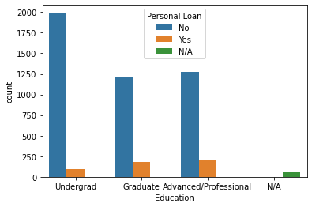

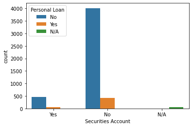

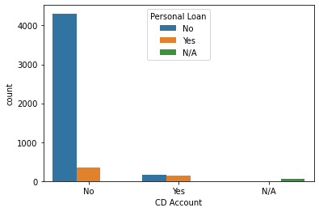

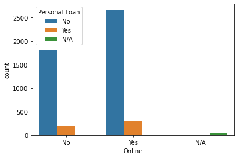

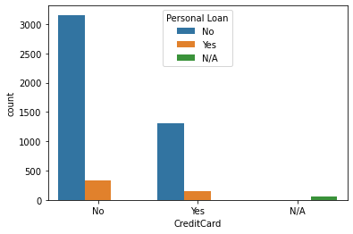

```python
# Check witch categorical variables have more loans

sns.countplot(bank_adj['Education'], hue=bank_adj['Personal Loan']);
plt.show()

sns.countplot(bank_adj['Securities Account'], hue=bank_adj['Personal Loan']);
plt.show()

sns.countplot(bank_adj['CD Account'], hue=bank_adj['Personal Loan']);
plt.show()

sns.countplot(bank_adj['Online'], hue=bank_adj['Personal Loan']);
plt.show()

sns.countplot(bank_adj['CreditCard'], hue=bank_adj['Personal Loan']);
plt.show()
```

### Categorical graphs shows that:

##### - Credit Card, online, Securities is not too visible on graphs

## f - Get data model ready

```python
#Drop data with fill erros  - ID = 20.1046 with all collums information as the same of ID
bank_model = bank_adj[(bank_adj['ID']!=20.1046)].copy()
```

```python
#double check categorical variables nbr
Cat_Vars = ['Education','Personal Loan','Securities Account','CD Account','Online','CreditCard']

for x,y in enumerate(Cat_Vars):
    print("{}\n ".format(bank_model.groupby(y)["ID"].count().sort_values(ascending = False)))
```

```
Education
Undergrad                2080
Advanced/Professional    1481
Graduate                 1387
Name: ID, dtype: int64

Personal Loan
No     4468
Yes     480
Name: ID, dtype: int64

Securities Account
No     4432
Yes     516
Name: ID, dtype: int64

CD Account
No     4646
Yes     302
Name: ID, dtype: int64

Online
Yes    2954
No     1994
Name: ID, dtype: int64

CreditCard
No     3493
Yes    1455
Name: ID, dtype: int64
```

```python
#Cat_Vars = ['Education','Personal Loan','Securities Account','CD Account','Online','CreditCard']
# change dummies

bank_model = pd.get_dummies(bank_model, columns=['Education'])
bank_model = pd.get_dummies(bank_model, columns=['Securities Account'])
bank_model = pd.get_dummies(bank_model, columns=['CD Account'])
bank_model = pd.get_dummies(bank_model, columns=['Online'])
bank_model = pd.get_dummies(bank_model, columns=['CreditCard'])
```

```python
bank_model.head()
# check table
```

|  | ID | Age | Experience | Income | ZIP Code | Family | CCAvg | Mortgage | Personal Loan | Education_Advanced/Professional | Education_Graduate | Education_Undergrad | Securities Account_No | Securities Account_Yes | CD Account_No | CD Account_Yes | Online_No | Online_Yes | CreditCard_No | CreditCard_Yes |
| --- | --- | --- | --- | --- | --- | --- | --- | --- | --- | --- | --- | --- | --- | --- | --- | --- | --- | --- | --- | --- |
| 0 | 1.00 | 25.00 | 1.00 | 49.00 | 91,107.00 | 4.00 | 1.60 | 0.00 | No | 0 | 0 | 1 | 0 | 1 | 1 | 0 | 1 | 0 | 1 | 0 |
| 1 | 2.00 | 45.00 | 19.00 | 34.00 | 90,089.00 | 3.00 | 1.50 | 0.00 | No | 0 | 0 | 1 | 0 | 1 | 1 | 0 | 1 | 0 | 1 | 0 |
| 2 | 3.00 | 39.00 | 15.00 | 11.00 | 94,720.00 | 1.00 | 1.00 | 0.00 | No | 0 | 0 | 1 | 1 | 0 | 1 | 0 | 1 | 0 | 1 | 0 |
| 3 | 4.00 | 35.00 | 9.00 | 100.00 | 94,112.00 | 1.00 | 2.70 | 0.00 | No | 0 | 1 | 0 | 1 | 0 | 1 | 0 | 1 | 0 | 1 | 0 |
| 4 | 5.00 | 35.00 | 8.00 | 45.00 | 91,330.00 | 4.00 | 1.00 | 0.00 | No | 0 | 1 | 0 | 1 | 0 | 1 | 0 | 1 | 0 | 0 | 1 |

```python
bank_model.dtypes
# check table datatypes- need to change Personal Loan to number
```

```
ID                                 float64
Age                                float64
Experience                         float64
Income                             float64
ZIP Code                           float64
Family                             float64
CCAvg                              float64
Mortgage                           float64
Personal Loan                       object
Education_Advanced/Professional      uint8
Education_Graduate                   uint8
Education_Undergrad                  uint8
Securities Account_No                uint8
Securities Account_Yes               uint8
CD Account_No                        uint8
CD Account_Yes                       uint8
Online_No                            uint8
Online_Yes                           uint8
CreditCard_No                        uint8
CreditCard_Yes                       uint8
dtype: object
```

```python
#Replace loan to Numbers
bank_model['Personal Loan'] = bank_model['Personal Loan'].replace({'Yes':1, 'No':0 })
bank_model
```

|  | ID | Age | Experience | Income | ZIP Code | Family | CCAvg | Mortgage | Personal Loan | Education_Advanced/Professional | Education_Graduate | Education_Undergrad | Securities Account_No | Securities Account_Yes | CD Account_No | CD Account_Yes | Online_No | Online_Yes | CreditCard_No | CreditCard_Yes |
| --- | --- | --- | --- | --- | --- | --- | --- | --- | --- | --- | --- | --- | --- | --- | --- | --- | --- | --- | --- | --- |
| 0 | 1.00 | 25.00 | 1.00 | 49.00 | 91,107.00 | 4.00 | 1.60 | 0.00 | 0 | 0 | 0 | 1 | 0 | 1 | 1 | 0 | 1 | 0 | 1 | 0 |
| 1 | 2.00 | 45.00 | 19.00 | 34.00 | 90,089.00 | 3.00 | 1.50 | 0.00 | 0 | 0 | 0 | 1 | 0 | 1 | 1 | 0 | 1 | 0 | 1 | 0 |
| 2 | 3.00 | 39.00 | 15.00 | 11.00 | 94,720.00 | 1.00 | 1.00 | 0.00 | 0 | 0 | 0 | 1 | 1 | 0 | 1 | 0 | 1 | 0 | 1 | 0 |
| 3 | 4.00 | 35.00 | 9.00 | 100.00 | 94,112.00 | 1.00 | 2.70 | 0.00 | 0 | 0 | 1 | 0 | 1 | 0 | 1 | 0 | 1 | 0 | 1 | 0 |
| 4 | 5.00 | 35.00 | 8.00 | 45.00 | 91,330.00 | 4.00 | 1.00 | 0.00 | 0 | 0 | 1 | 0 | 1 | 0 | 1 | 0 | 1 | 0 | 0 | 1 |
| ... | ... | ... | ... | ... | ... | ... | ... | ... | ... | ... | ... | ... | ... | ... | ... | ... | ... | ... | ... | ... |
| 4995 | 4,996.00 | 29.00 | 3.00 | 40.00 | 92,697.00 | 1.00 | 1.90 | 0.00 | 0 | 1 | 0 | 0 | 1 | 0 | 1 | 0 | 0 | 1 | 1 | 0 |
| 4996 | 4,997.00 | 30.00 | 4.00 | 15.00 | 92,037.00 | 4.00 | 0.40 | 85.00 | 0 | 0 | 0 | 1 | 1 | 0 | 1 | 0 | 0 | 1 | 1 | 0 |
| 4997 | 4,998.00 | 63.00 | 39.00 | 24.00 | 93,023.00 | 2.00 | 0.30 | 0.00 | 0 | 1 | 0 | 0 | 1 | 0 | 1 | 0 | 1 | 0 | 1 | 0 |
| 4998 | 4,999.00 | 65.00 | 40.00 | 49.00 | 90,034.00 | 3.00 | 0.50 | 0.00 | 0 | 0 | 1 | 0 | 1 | 0 | 1 | 0 | 0 | 1 | 1 | 0 |
| 4999 | 5,000.00 | 28.00 | 4.00 | 83.00 | 92,612.00 | 3.00 | 0.80 | 0.00 | 0 | 0 | 0 | 1 | 1 | 0 | 1 | 0 | 0 | 1 | 0 | 1 |

4948 rows × 20 columns

```python
#Change loan datatype
bank_model['Personal Loan'] = bank_model['Personal Loan'] .astype('float64')
```

```python
#Check Data
bank_model.dtypes
```

```
ID                                 float64
Age                                float64
Experience                         float64
Income                             float64
ZIP Code                           float64
Family                             float64
CCAvg                              float64
Mortgage                           float64
Personal Loan                      float64
Education_Advanced/Professional      uint8
Education_Graduate                   uint8
Education_Undergrad                  uint8
Securities Account_No                uint8
Securities Account_Yes               uint8
CD Account_No                        uint8
CD Account_Yes                       uint8
Online_No                            uint8
Online_Yes                           uint8
CreditCard_No                        uint8
CreditCard_Yes                       uint8
dtype: object
```